# 678 Final Project Report

Haochen Pan

## Part1 Abstract

In the database recommended by Japanese animation, I found data about a large number of animation ratings, including numerical data such as animation scores, number of participants, and variables of more than 10 groups such as producer and source. This report will use multilevel modeling to analyze the how popularity and number of community fans and other variables affect the rating of anime (and some interesting conclusions/guess about anime-rating). The 10 page pdf is not enough for all graphs and analysis. There is a larger one in the github.

## Part2 Introduction

The name of the data set from Kaggle is called “anime recommendation”, which contains information on user preference data from 73,516 users on 12,294 anime. In the excel from the data, some useful variables can be used to find which variables can affect the rating of animes and how they exactly affect the rating. The following contents are the explanation of each variable.

Anime_id: myanimelist.net’s unique id identifying an anime. Title: full name of anime. Type: Movie, TV, Special, etc. Producer: Different producer companies that produce the anime. Studio: The creator company of anime. Rating: Average rating out of 10 for this anime. ScoreBy: Number of people who rate the anime. Popularity: The popularity of the anime(the lower number means more famous). Members: Number of community fans that are in this anime’s “group”. Episodes: How many episodes in this show. (1 if movie). Source: The source of the anime, including Manga, original, etc. Aired: The date that the anime start to show.

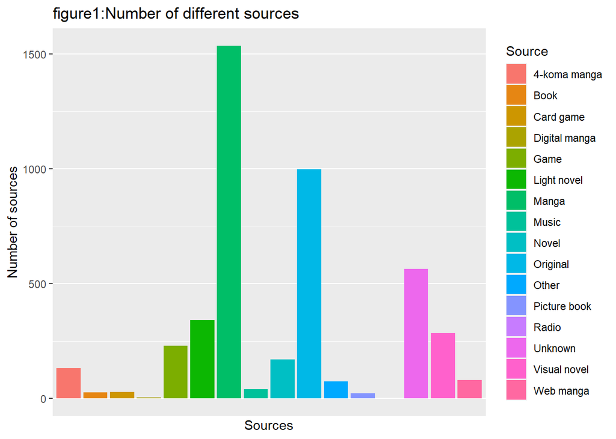

## Part3 Methods

### Data Cleaning

In the uploading part, I delete the missing data and NAs.

### EDA

Before the linear regression and modeling, I first use some variables mentioned above to make graphs to predict which methods are more useful in the next parts.

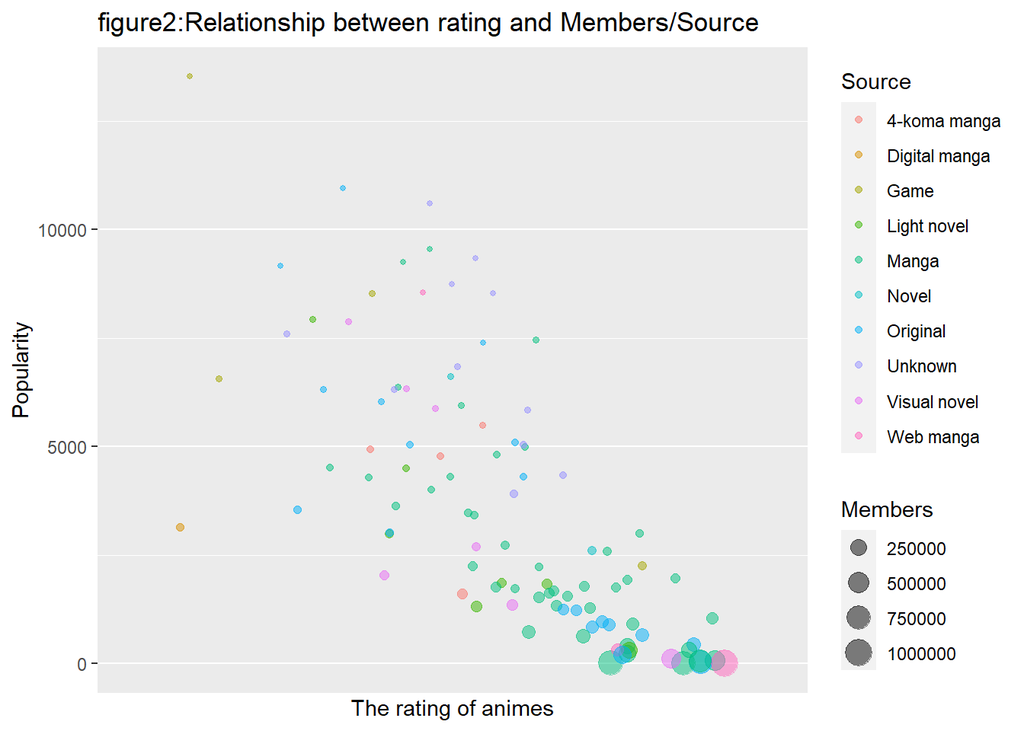

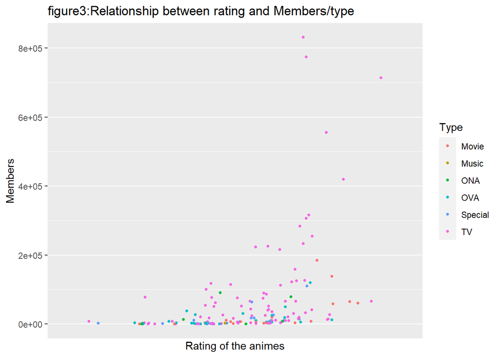

### Linear Model

First, I use linear model to analysis how Popularity/Members affect Rating

```
##
## Call:
## lm(formula = Rating ~ log(Popularity) + log(Members) + log(ScoredBy),
##     data = sample_2)
##
## Residuals:
##     Min      1Q  Median      3Q     Max
## -2.1280 -0.3662  0.0502  0.4441  1.4223
##
## Coefficients:
##                 Estimate Std. Error t value Pr(>|t|)
## (Intercept)      6.29262    1.50325   4.186 4.88e-05 ***
## log(Popularity) -0.09608    0.10638  -0.903    0.368
## log(Members)     0.02381    0.17012   0.140    0.889
## log(ScoredBy)    0.14188    0.12748   1.113    0.268
## ---
## Signif. codes:  0 '***' 0.001 '**' 0.01 '*' 0.05 '.' 0.1 ' ' 1
##
## Residual standard error: 0.646 on 146 degrees of freedom
## Multiple R-squared:  0.3862, Adjusted R-squared:  0.3736
## F-statistic: 30.62 on 3 and 146 DF,  p-value: 2.046e-15
```

```
##     (Intercept) log(Popularity)    log(Members)   log(ScoredBy)
##      6.29262008     -0.09607792      0.02380838      0.14187832
```

|  | 2.5 % | 97.5 % |
| --- | --- | --- |
| (Intercept) | 3.32 | 9.26 |
| log(Popularity) | -0.31 | 0.11 |
| log(Members) | -0.31 | 0.36 |
| log(ScoredBy) | -0.11 | 0.39 |

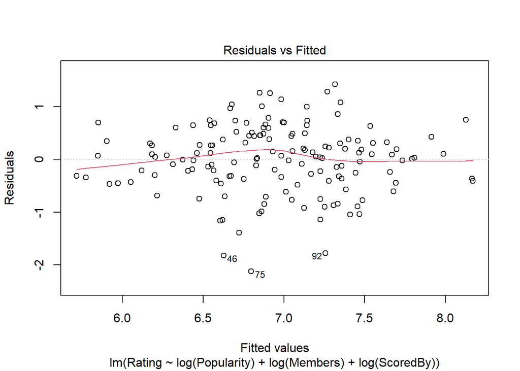

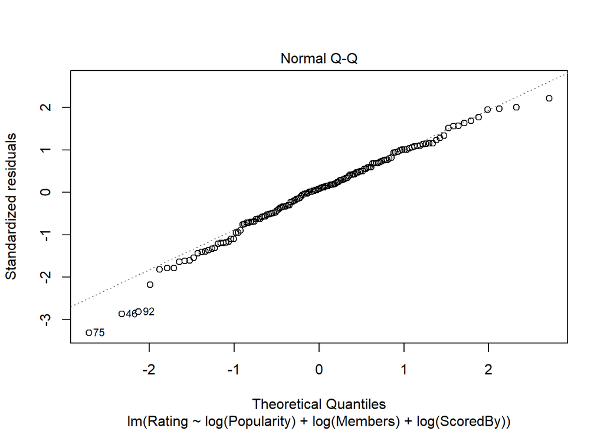

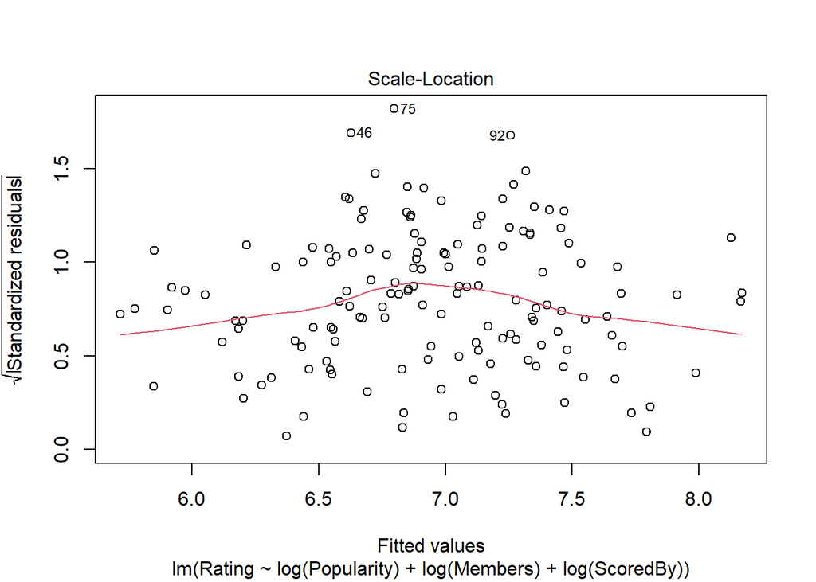

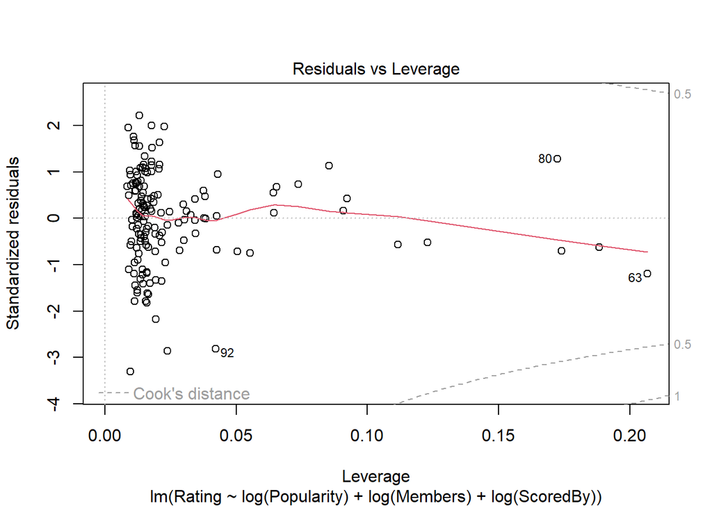

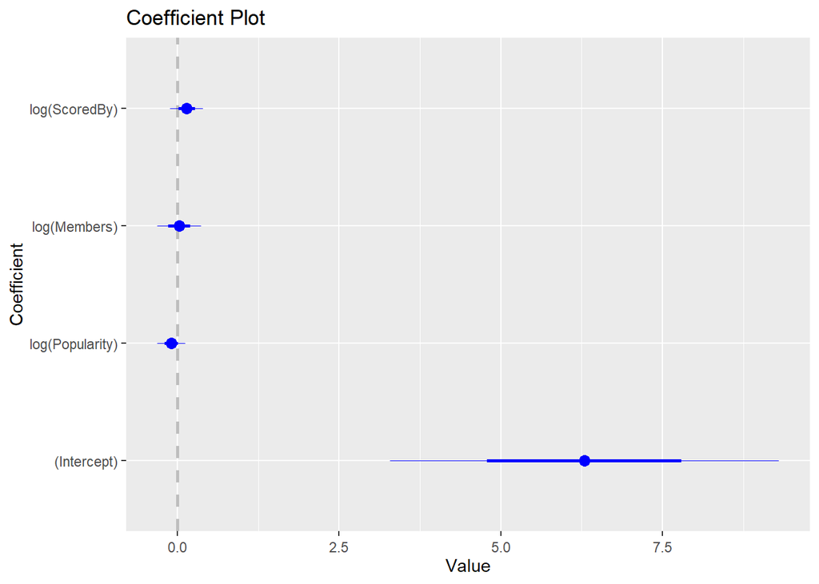

### Multilevel Modeling

Then, based on the requirement, i use the multilevel model to analysis and predict the data. First, I check the distributions by type/source.

[output not shown]

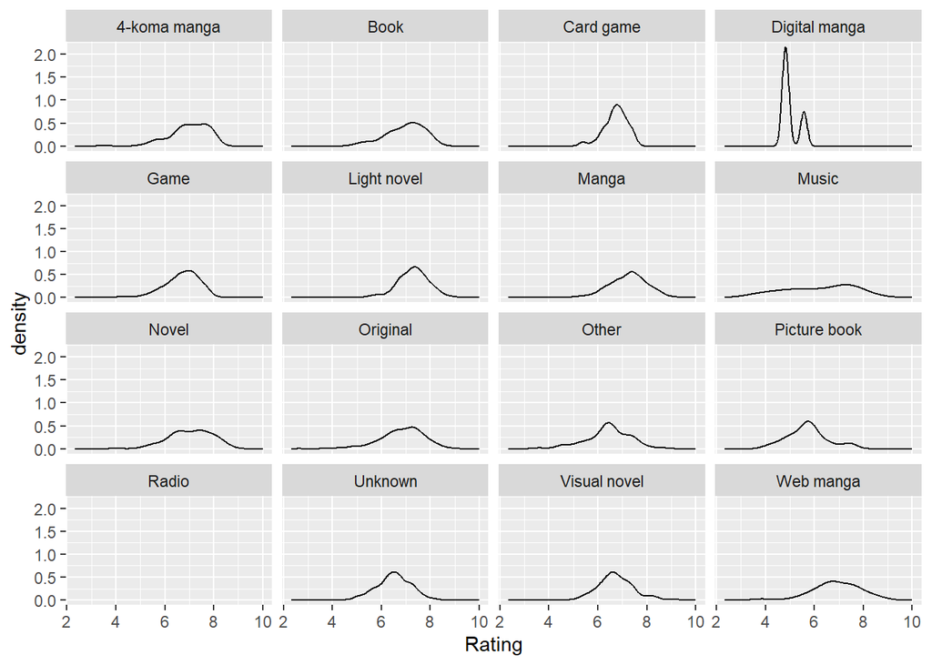

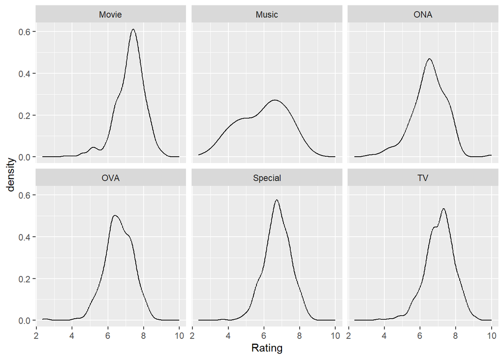

```
## Linear mixed model fit by maximum likelihood  ['lmerMod']
## Formula: Rating ~ 1 + (1 | Type)
##    Data: data2
##
##      AIC      BIC   logLik deviance df.resid
##  11074.3  11093.6  -5534.2  11068.3     4521
##
## Scaled residuals:
##     Min      1Q  Median      3Q     Max
## -5.2171 -0.5895  0.0571  0.6723  4.2638
##
## Random effects:
##  Groups   Name        Variance Std.Dev.
##  Type     (Intercept) 0.1698   0.4121
##  Residual             0.6720   0.8198
## Number of obs: 4524, groups:  Type, 6
##
## Fixed effects:
##             Estimate Std. Error t value
## (Intercept)   6.6946     0.1698   39.44
```

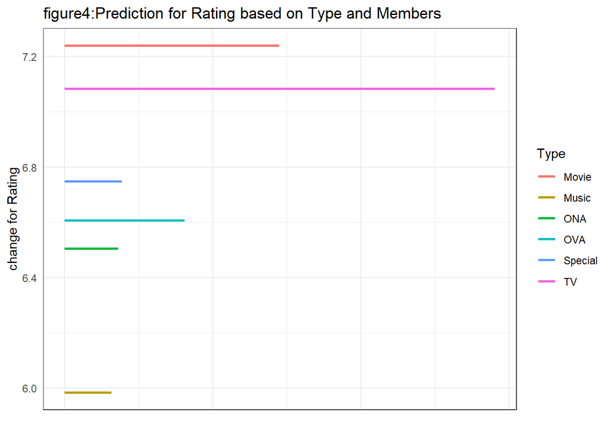

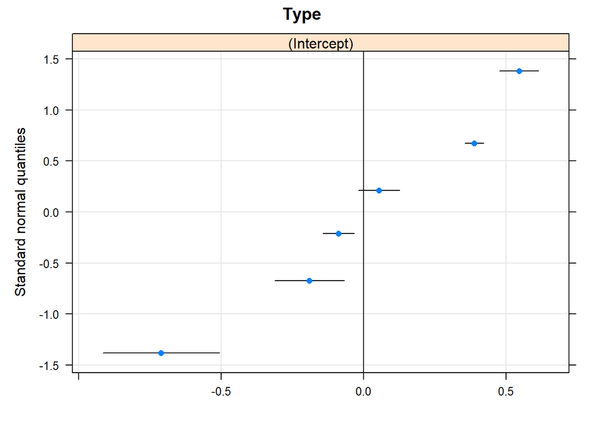

```
## Linear mixed model fit by maximum likelihood  ['lmerMod']
## Formula: Rating ~ 1 + (1 | Source)
##    Data: data2
##
##      AIC      BIC   logLik deviance df.resid
##  10941.8  10961.0  -5467.9  10935.8     4521
##
## Scaled residuals:
##     Min      1Q  Median      3Q     Max
## -5.4524 -0.5965  0.0673  0.6696  3.9419
##
## Random effects:
##  Groups   Name        Variance Std.Dev.
##  Source   (Intercept) 0.2059   0.4538
##  Residual             0.6487   0.8054
## Number of obs: 4524, groups:  Source, 16
##
## Fixed effects:
##             Estimate Std. Error t value
## (Intercept)   6.6694     0.1203   55.42
```

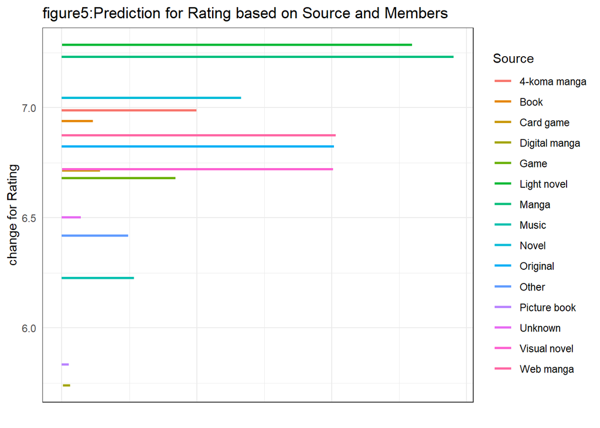

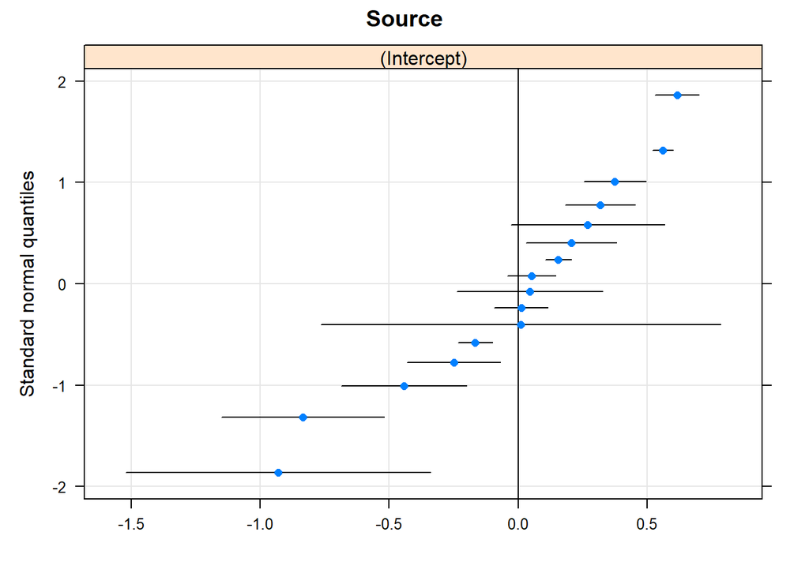

Each Type/Source is able to have a different increasing/decreasing of rating. Different Type and Source will affect the changing of rating.

```
## Linear mixed model fit by maximum likelihood  ['lmerMod']
## Formula: Rating ~ 1 + Members + (1 | Type)
##    Data: data2
##
##      AIC      BIC   logLik deviance df.resid
##  10171.7  10197.4  -5081.9  10163.7     4520
##
## Scaled residuals:
##     Min      1Q  Median      3Q     Max
## -5.8508 -0.5443  0.0744  0.6550  4.7800
##
## Random effects:
##  Groups   Name        Variance Std.Dev.
##  Type     (Intercept) 0.1260   0.3549
##  Residual             0.5503   0.7418
## Number of obs: 4524, groups:  Type, 6
##
## Fixed effects:
##              Estimate Std. Error t value
## (Intercept) 6.599e+00  1.464e-01   45.08
## Members     3.072e-06  9.708e-08   31.64
##
## Correlation of Fixed Effects:
##         (Intr)
## Members -0.021
## fit warnings:
## Some predictor variables are on very different scales: consider rescaling
```

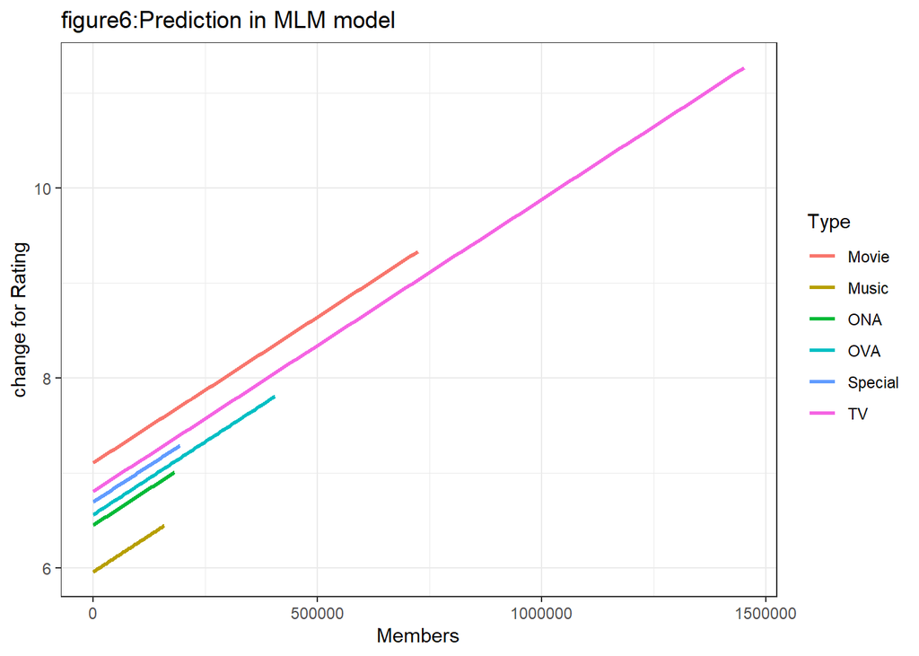

```
## Linear mixed model fit by maximum likelihood  ['lmerMod']
## Formula: Rating ~ 1 + Members + (1 | Source)
##    Data: data2
##
##      AIC      BIC   logLik deviance df.resid
##  10087.9  10113.6  -5040.0  10079.9     4520
##
## Scaled residuals:
##     Min      1Q  Median      3Q     Max
## -5.9247 -0.5648  0.0863  0.6856  4.5209
##
## Random effects:
##  Groups   Name        Variance Std.Dev.
##  Source   (Intercept) 0.1448   0.3805
##  Residual             0.5372   0.7329
## Number of obs: 4524, groups:  Source, 16
##
## Fixed effects:
##              Estimate Std. Error t value
## (Intercept) 6.546e+00  1.016e-01   64.44
## Members     2.932e-06  9.550e-08   30.70
##
## Correlation of Fixed Effects:
##         (Intr)
## Members -0.042
## fit warnings:
## Some predictor variables are on very different scales: consider rescaling
```

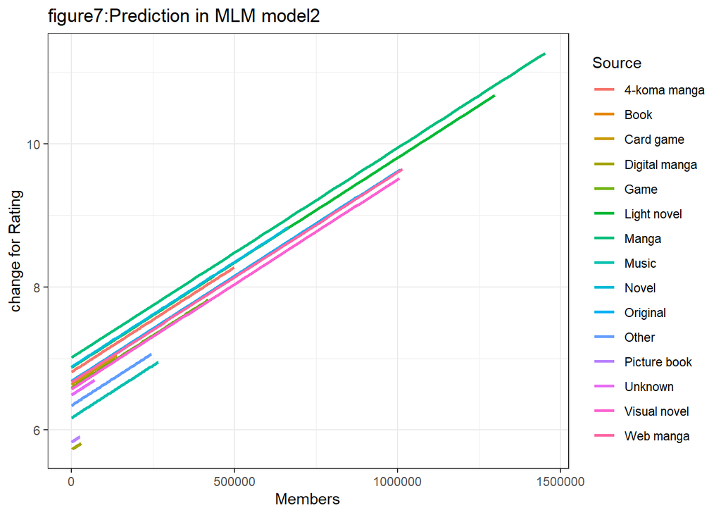

Here we see that as Members of group increases by 1 unit the rating increases by 3.072e-06 and 2.932e-06. We also notice that the random effects are smaller compared to the previous model. This indicates that number of members for group is explaining some variation.

```
## Linear mixed model fit by maximum likelihood  ['lmerMod']
## Formula: Rating ~ 1 + Members + (1 + Members | Type)
##    Data: data2
##
##      AIC      BIC   logLik deviance df.resid
##   9947.8   9986.3  -4967.9   9935.8     4518
##
## Scaled residuals:
##     Min      1Q  Median      3Q     Max
## -6.3266 -0.5321  0.0827  0.6548  5.1594
##
## Random effects:
##  Groups   Name        Variance  Std.Dev.  Corr
##  Type     (Intercept) 3.149e-01 0.5611190
##           Members     1.637e-08 0.0001279 -0.79
##  Residual             5.163e-01 0.7185228
## Number of obs: 4524, groups:  Type, 6
##
## Fixed effects:
##              Estimate Std. Error t value
## (Intercept) 6.483e+00  2.301e-01  28.175
## Members     1.237e-05  5.223e-05   0.237
##
## Correlation of Fixed Effects:
##         (Intr)
## Members -0.783
## fit warnings:
## Some predictor variables are on very different scales: consider rescaling
## optimizer (nloptwrap) convergence code: 0 (OK)
## unable to evaluate scaled gradient
## Model failed to converge: degenerate  Hessian with 1 negative eigenvalues
```

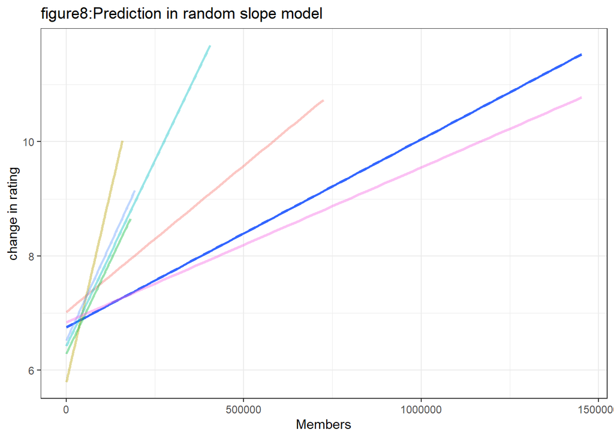

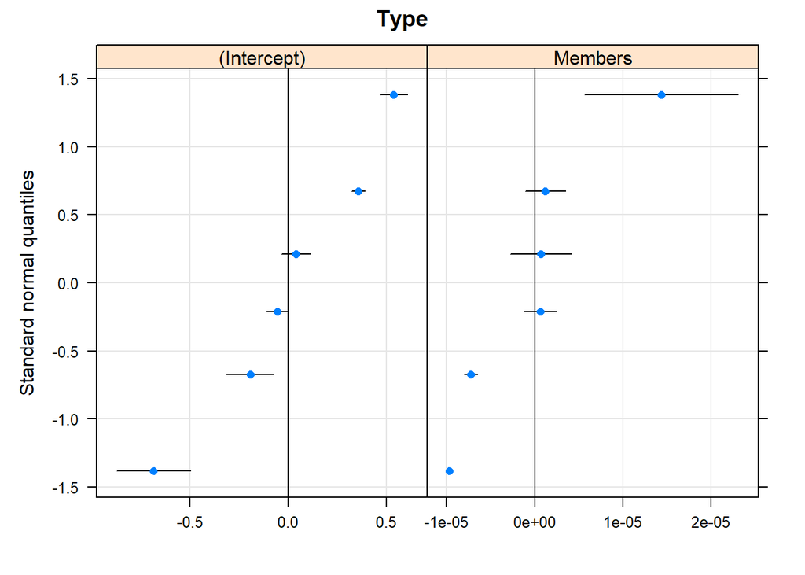

```
## Linear mixed model fit by maximum likelihood  ['lmerMod']
## Formula: Rating ~ 1 + Members + (1 + Members | Source)
##    Data: data2
##
##      AIC      BIC   logLik deviance df.resid
##  10028.7  10067.2  -5008.3  10016.7     4518
##
## Scaled residuals:
##     Min      1Q  Median      3Q     Max
## -6.0449 -0.5657  0.1024  0.6753  4.6977
##
## Random effects:
##  Groups   Name        Variance  Std.Dev.  Corr
##  Source   (Intercept) 5.118e-01 0.7153685
##           Members     1.226e-08 0.0001107 -0.54
##  Residual             5.129e-01 0.7161619
## Number of obs: 4524, groups:  Source, 16
##
## Fixed effects:
##              Estimate Std. Error t value
## (Intercept) 6.468e+00  1.871e-01  34.573
## Members     1.189e-05  2.871e-05   0.414
##
## Correlation of Fixed Effects:
##         (Intr)
## Members -0.542
## fit warnings:
## Some predictor variables are on very different scales: consider rescaling
## optimizer (nloptwrap) convergence code: 0 (OK)
## unable to evaluate scaled gradient
## Model failed to converge: degenerate  Hessian with 1 negative eigenvalues
```

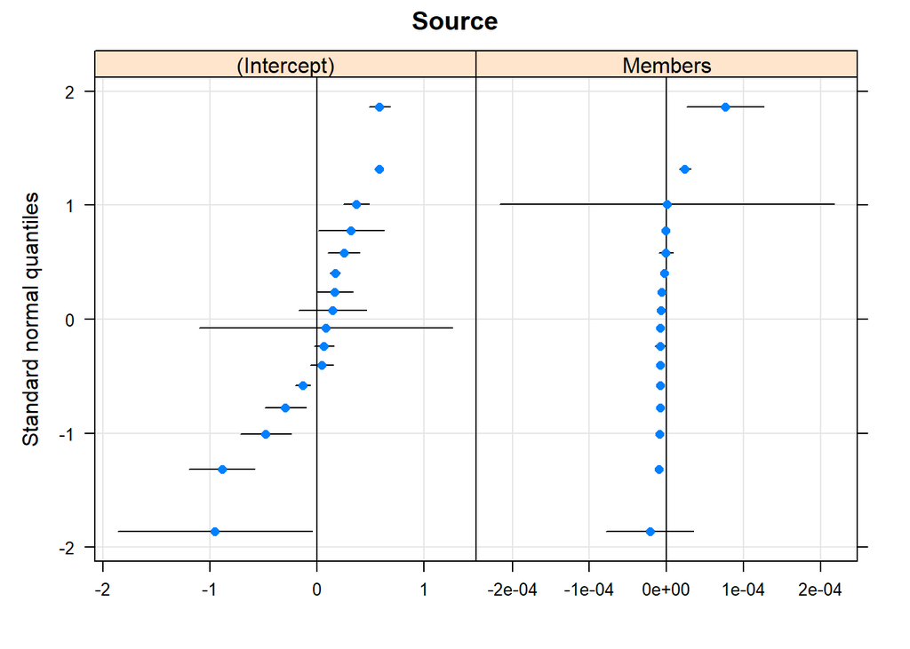

We see that there is a average effect that is represented by the fixed effect (1.237e-05) but each type is allowed to have its own line. Also, Source is no longer useful in this visualization.

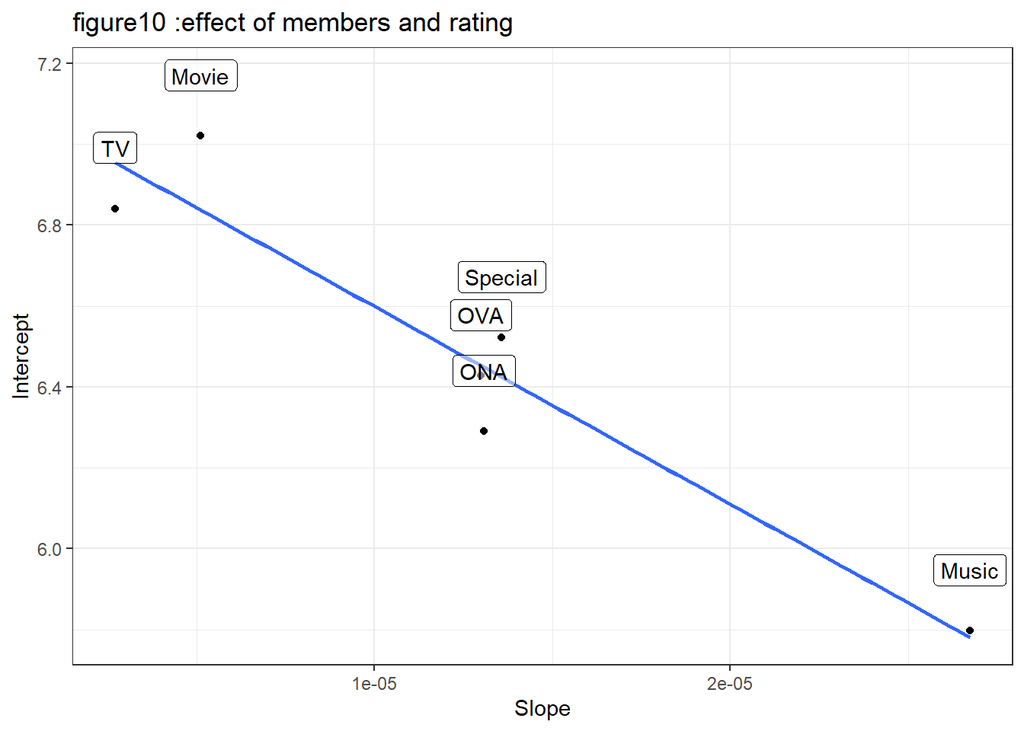

In figure The graphs shows that we can divide the types into 3 parts. TV and Movie have most members and high increasing in rating but low effect of members to outcome. The Music has low support in rating but members for music has strong effect. The interpret ion will be written in the result/discussion part.

### K-means algorithm

For this part, I want to use k-means to cluster observations and want observations in the same group to be similar and observations in different groups to be dissimilar.

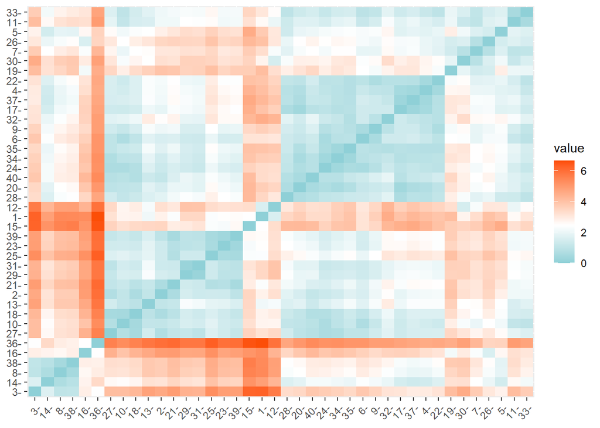

[output not shown]

```
## K-means clustering with 2 clusters of sizes 8, 32
##
## Cluster means:
##      Anime_id     Rating   Members Popularity
## 1  0.10784014  1.1270275  1.754964 -1.1610371
## 2 -0.02696003 -0.2817569 -0.438741  0.2902593
##
## Clustering vector:
##  [1] 2 2 1 2 1 2 2 1 2 2 2 2 2 1 2 1 2 2 2 2 2 2 2 2 2 1 2 2 2 2 2 2 2 2 2 1 2 1
## [39] 2 2
##
## Within cluster sum of squares by cluster:
## [1] 19.61538 79.28735
##  (between_SS / total_SS =  36.6 %)
##
## Available components:
##
## [1] "cluster"      "centers"      "totss"        "withinss"     "tot.withinss"
## [6] "betweenss"    "size"         "iter"         "ifault"
```

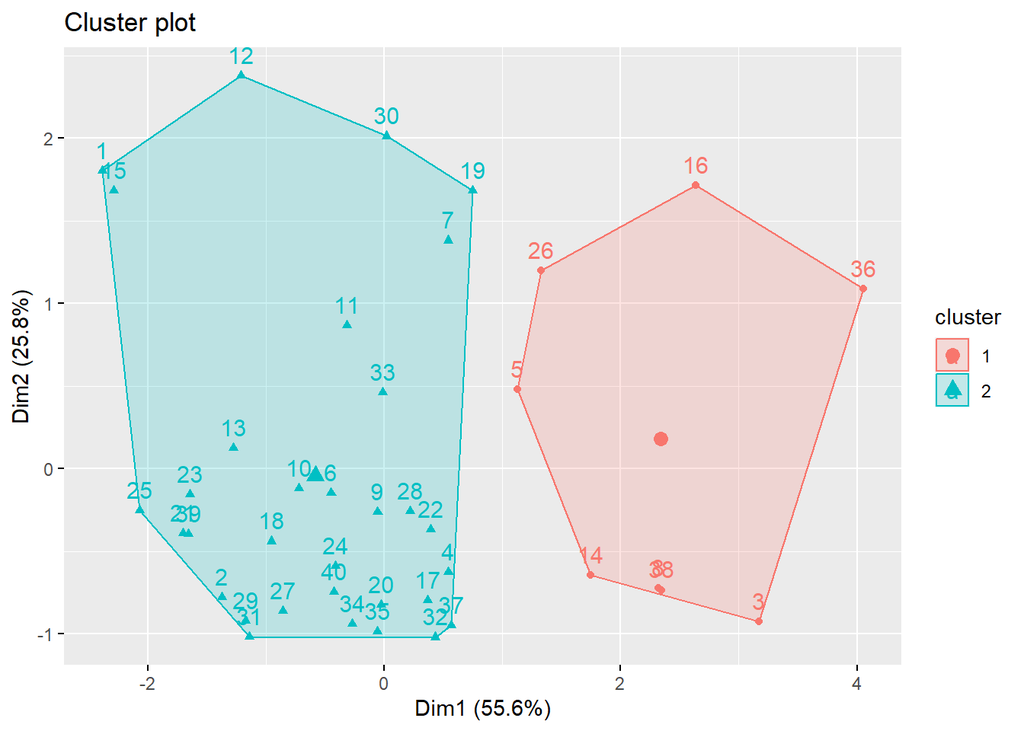

### Word Could and Tpoic Modeling

Finally, I tried what I learn in 615 to analysis the non-numerical data.

| word | n |
| --- | --- |
| Comedy | 5272 |
| Action | 3404 |
| Fantasy | 2874 |
| Adventure | 2558 |
| Drama | 2350 |
| Fi | 2259 |
| Sci | 2259 |
| Kids | 2249 |
| Shounen | 1784 |
| Music | 1717 |

[output cut: 36 more lines]

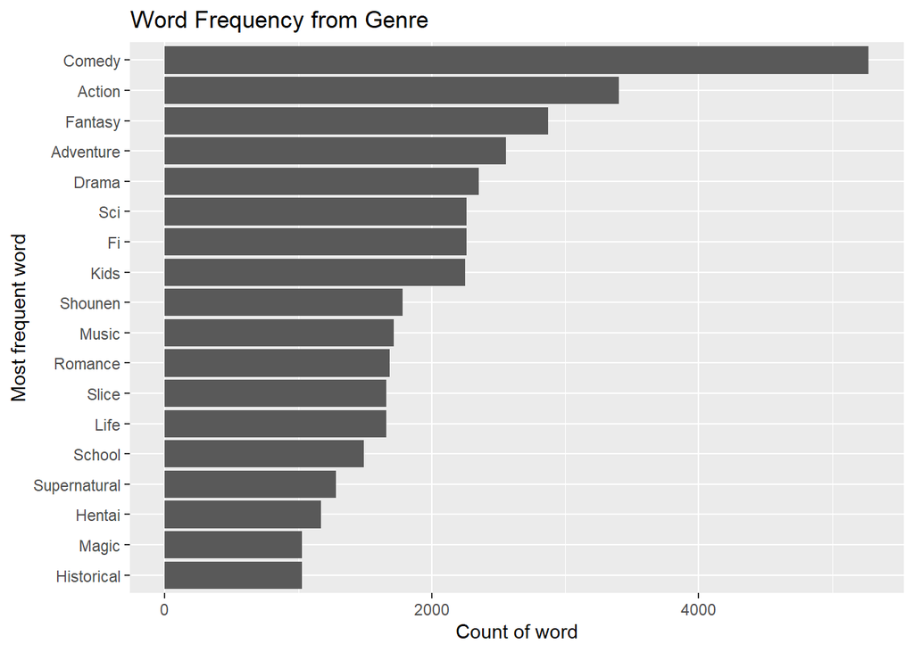

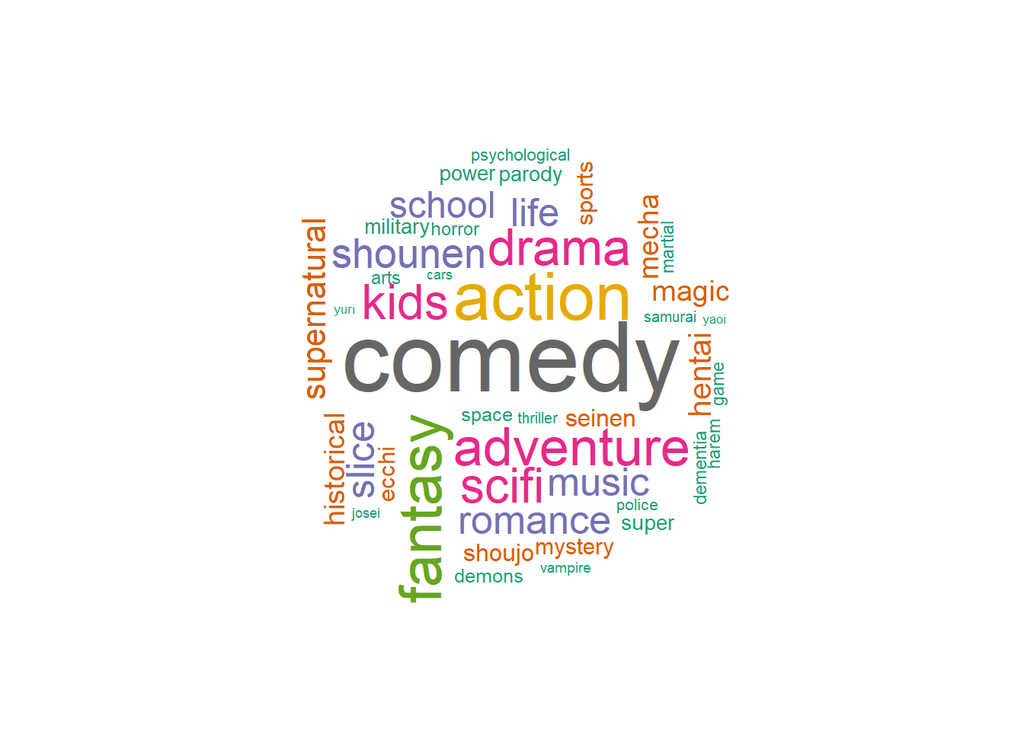